# Assignment 4

Based on mean values:

JNJ, MRK, PFE, and GSK comprise Cluster 1. The highest metrics in this cluster are Market_cap, ROA, ROE, and Asset_Turnover; the lowest are Beta and PE_Ratio.

CHTT, ELN, MRX, and IVX make up Cluster 3; it has the lowest Market Cap, ROE, ROA, Leverage, Rev Growth, and Net Profit Margin, and the highest Beta and Leverage.

BAY, PHA, and AGN make up Cluster 4, which has the lowest leverage and asset turnover ratios and the highest PE ratio.

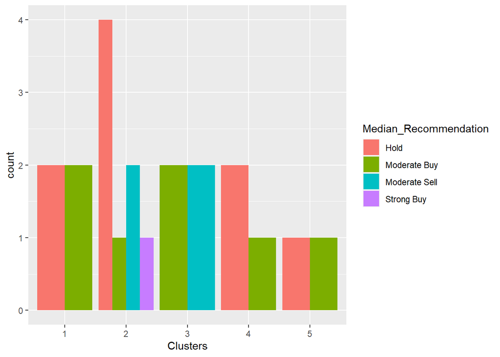

```r
clustdata <- Pharmac[12:14] %>% mutate(Clusters=k5$cluster)
ggplot(clustdata, mapping = aes(factor(Clusters), fill = Median_Recommendation))+geom_bar(position='dodge')+labs(x= 'Clusters')
```

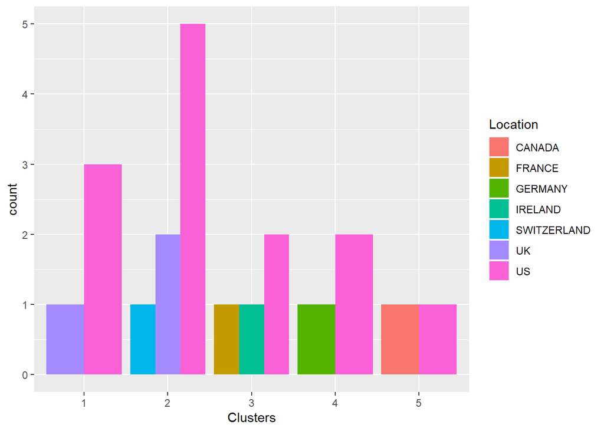

```r
ggplot(clustdata, mapping = aes(factor(Clusters),fill = Location))+geom_bar(position = 'dodge')+labs(x ='Clusters')
```

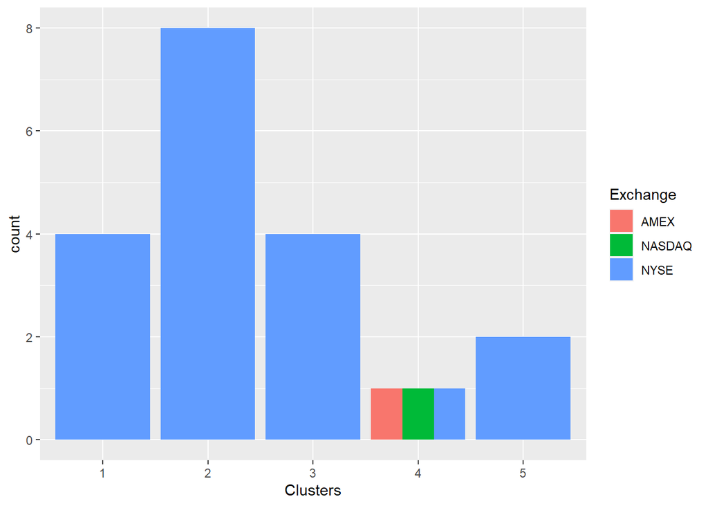

```r
ggplot(clustdata, mapping = aes(factor(Clusters),fill = Exchange))+geom_bar(position = 'dodge')+labs(x ='Clusters')
```

The variable and clusters there is a trend in the median recommendations. There doesn’t seem to be any discernable pattern among the clusters, locations, or exchanges other than the fact that the majority of the clusters/companies are listed on the NYSE and situated in the United States

3.Provide an appropriate name for each cluster using any or all of the variables in the dataset.

Cluster 1: Top Buying

Cluster 2: Significant Risk

Cluster 3: Attempt it

Cluster 4: Very Dangerous or Runaway

Cluster 5: A Perfect Asset